# Devoir 3

Aloui Mohamed, Jafuno Douba

14 décembre 2018

## Question 1: Tailles des effectifs

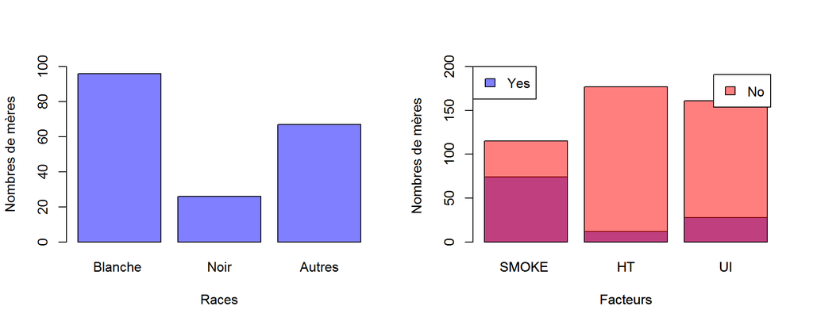

**Tableau des effectifs de RACE**

| RACE | Effectif |
| --- | --- |
| Blanche | 96 |
| Noir | 26 |
| Autres | 67 |

**Tableau des effectifs de SMOKE HT et UI**

| . | Smoke | HT | UI |
| --- | --- | --- | --- |
| Yes | 74 | 12 | 28 |
| No | 115 | 177 | 161 |

Grace aux graphiques et aux tableaux ci dessus on voit bien que pour chaque variable la taille des groupes est différentes, autrement dit le plan d’expérience n’est pas équilibré en chaque variable.

## Question 2: Modèle à un facteur

### 1) Visualisation de l’impact

Afin de visualiser l’impact du facteur sur la variable à expliquer on peut tracer des boxplots :

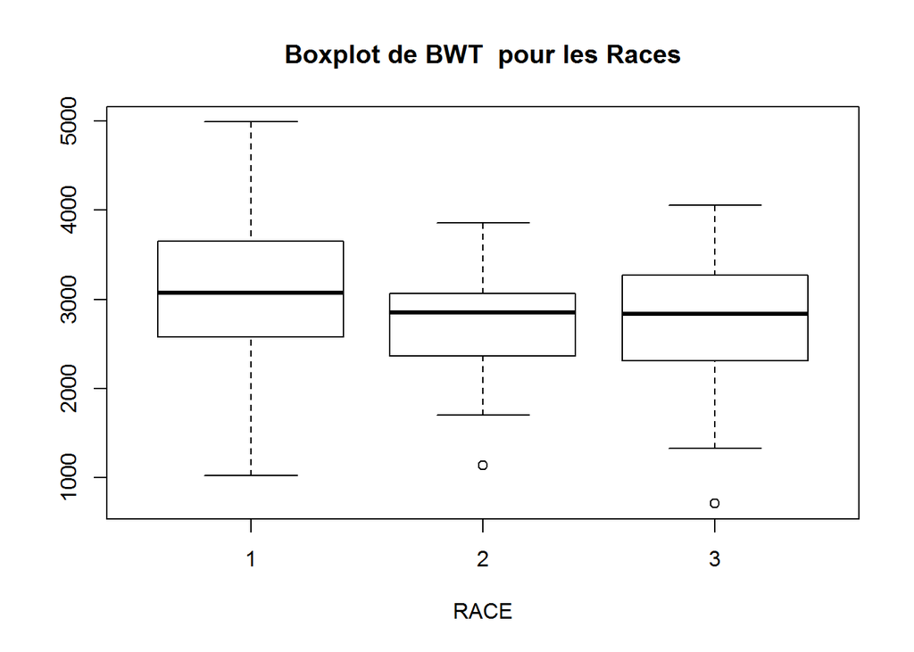

On observe que les trois boxplots sont légèrement different avec une echelle du poids à la naissance plus grande quand il s’agit d’une femme de la race 1 que pour les deux autres races.

### 2) RACE variable qualitative

On considère le modèle: $\text{BWT}_{i}$ = $\beta_0 + \beta_1\text{RACE} +\varepsilon$ ici la variable RACE est interpréter comme une variable quantitative. , Mais en réalité la variable RACE est de type qualitative, ce modèle n’a donc aucun sens d’un point de vue d’interprétation.

Observons alors ce qui se passe en la définissant comme une variable qualitative, c’est à dire en la déclarant comme une variable de type factor.

### 3) Tableau des coefficients de la Fonction lm

| . | Estimate | Std. Error | t value | Pr(>abs(t) |  |
| --- | --- | --- | --- | --- | --- |
| (Intercept) | 3103.74 | 72.88 | 42.586 | < 2e-16 |  |
| RACE2 | -384.05 | 157.87 | -2.433 | 0.01594 |  |
| RACE3 | -299.72 | 113.68 | -2.637 | 0.00908 |  |

On observe qu’il s’agit d’un modèle de type analyse de la variance à 1 facteur en effet le tableau des **Coefficients** est composé de trois lignes (**Intercept**, **RACE2** et **RACE3**).

Avec les observations $\text{BWT}_{i,j}$ on considère donc le modèle suivant:
$$\text{BWT}_{ij} = \mu_1+ \alpha_i +\varepsilon_{ij}, \qquad i=1,\dots,I\quad j=1,\dots,n_i.$$
où l’indice $i$ indique la race (1, 2 ou 3), $\mu_i$ les moyennes de ses groupes avec la contrainte $\alpha_1=0$, on a $\mathcal\varepsilon_{ij}$~ $N(0,\sigma²)$. Autrement dit, les $\alpha_i$ pour $i=2,\dots,I$ vérifient
$$\alpha_i= \mu_i-\mu_1,$$
on voit alors que tout les autres paramètres (pour $i>1$) dépendent du niveau $i=1$

La colonne **Estimate** contient les estimateurs de $\mu_1$ (**Intercept**: 3103.74), de $\alpha_2$ (**RACE2**: -384.05 ) et de $\alpha_3$ (**RACE3**:-299.72).

La colonnes **t value** représente la valeur observée de la statistique du test d’hypothèse $H_0$:$\mu_1$=$\alpha_2$=$\alpha_3$= 0 contre $H_1:\mu_1\neq 0 ,\alpha_2\neq 0$ et $\alpha_3\neq 0$

Les tests de significativité des coefficients (**Pr(>|t|)**) donnent ici des p-valeurs inférieures à 0.05: 0.01594 et 0.00908

La très petite p-valeur (2e-16) pour la constante indique que la constante (l’intercept) doit apparaître dans le modèle.

Tout cela montre bien que les coefficients **RACE 2** et **RACE 3** sont significatives sur le poids de naissance du bébé (**BWT**) ainsi l’hypothèse nulle $H_0$ de chacun des tests est rejetée au profit de l’hypothèse alternative $H_1$

### 4) Tableau de l’analyse de la variance

| . | Df | Sum Sq | Mean Sq | F value | Pr(>F) |  |
| --- | --- | --- | --- | --- | --- | --- |
| RACE | 2 | 5070608 | 2535304 | 4.9719 | 0.007879 |  |
| Residuals | 186 | 94846445 | 509927 |  |  |  |

**Df** signifie degree of freedom. **Sum Sq** et **Mean Sq** renseignent les différentes SCE et CME.

La colonne **F value** donne la valeur de la statistique de test F en sur ce jeu de données.

La dernière colonne **Pr(>F)** est la plus importante car elle permet de conclure pour notre test.

En fait, **Pr(>F)** est la p-value du test de l’absence d’effet dû au facteur (RACE) dans le cas du poids de naissance du bébé (BWT).

Rappelons qu’en général, si la p-value est petite (< 0.01), on rejette $H_0$ et on décide $H_1$. **Ici, on voit que la p-value du test de l’absence d’effet dû à la RACE est de 0.007879, ce qui est clairement en faveur de l’hypothèse $H_1$.**

**Il n’y a pas de doute que la RACE de la mère influence significativement sur le poids de naissance du bébé**.

## Question 3: Lm avec les variables SMOKE, UI et HT

Coefficients pour Smoke Modèle 1:

| . | Estimate | Std. Error | t value | Pr(>abs(t) |  |
| --- | --- | --- | --- | --- | --- |
| (Intercept) | 3054.96 | 66.93 | 45.642 | < 2e-16 |  |
| SMOKEY | -281.71 | 106.97 | -2.634 | 0.00916 |  |

Coefficients pour HT Modèle 2:

| . | Estimate | Std. Error | t value | Pr(>abs(t) |  |
| --- | --- | --- | --- | --- | --- |
| (Intercept) | 2972.31 | 54.35 | 54.685 | <2e-16 |  |
| HTY | -435.56 | 215.71 | -2.019 | 0.0449 |  |

Coefficients pour UI Modèle 3:

| . | Estimate | Std. Error | t value | Pr(>abs(t) |  |
| --- | --- | --- | --- | --- | --- |
| (Intercept) | 3030.61 | 55.25 | 54.857 | < 2e-16 |  |
| UIY | -580.18 | 143.53 | -4.042 | 7.73e-05 |  |

Pour le modèle 1 (resp 2, resp 3) On voit qu’il s’agit d’un modèle de type analyse de la variance à 1 facteur en effet le tableau des **Coefficients** est composé de deux lignes (**Intercept**, **SMOKEY**( resp **HTY**, resp **UIY**).

Pour Smoke resp(HT),resp(UI) on considère le modèle 1 (resp 2, resp 3) suivant:
$$\text{BWT}_{ij} = \mu_1+ \alpha_i +\varepsilon_{ij}, \qquad i=1,\dots,I\quad j=1,\dots,n_i.$$
où l’indice $i$ indique (1 pour No et 2 pour Yes), $\mu_i$ les moyennes de ses groupes avec la contrainte $\alpha_1=0$, on a $\mathcal\varepsilon_{ij}$~ $N(0,\sigma²)$. Autrement dit, les $\alpha_i$ pour $i=2,\dots,I$ vérifient
$$\alpha_i= \mu_i-\mu_1,$$
on voit alors que le paramètre pour $i=2(Y)$ dépend du niveau $i=1(N)$

La colonne **Estimate** contient les estimateurs de $\mu_1$ **Intercept**: 3054.96 (resp 2972.31, resp 3030.61), et $\alpha_2$ **SMOKEY**: -281.71 (resp **HTY**: -435.56, resp **UIY**: -580.18 )

La colonnes **t value** représente la valeur observée de la statistique du test d’hypothèse $H_0$:$\mu_1$=$\alpha_2$= 0 contre $H_1:\mu_1\neq 0$ et $\alpha_2\neq 0$

Les tests de significativité des coefficients (**Pr(>|t|)**) donnent ici des p-valeurs inférieures à 0.05: 0.00916 (resp 0.0449, resp 7.73e-05)

La très petite p-valeur (2e-16) pour la constante indique que la constante (l’intercept) doit apparaître dans le modèle.

Tout cela montre bien que **le test du coefficient SMOKEY (resp HTY , resp UIY) est significative sur le poids de naissance du bébé (BWT)** ainsi l’hypothèse nulle $H_0$ de chacun des tests est rejetée au profit de l’hypothèse alternative

## Question 4: Modèle à deux facteurs

### 1) Analyse de l’impact des facteurs

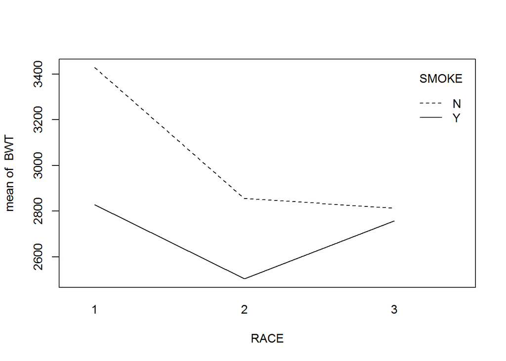

Nous pouvons voir que la courbe des moyennes de poids de naissance associées aux non-fumeurs est plus élevée que celle des fumeurs quelque soit la race de la mère. **Il semble donc avoir un impact du tabagisme (SMOKE) sur le poids de naissance**.

### 2) Tableau des coefficients de lm

On considère comme dans le cours le modèle à deux facteurs avec interaction donné par

$$\text{BWT}_{ijk} = \mu_{11}+ \alpha_i + \beta_j + \gamma_{ij} +\varepsilon_{ij},$$
avec les contraintes $\alpha_1=0$, $\beta_1=0$, $\gamma_{1j}=0, j=1,\dots,J$ et $\gamma_{i1}=0,i=1,\dots,I$. On le tableau des coefficients suivant :

| . | Estimate | Std. Error | t value | Pr(>abs(t) |  |
| --- | --- | --- | --- | --- | --- |
| (Intercept) | 3428.8 | 103.0 | 33.278 | < 2e-16 |  |
| SMOKEY | -600.0 | 140.0 | -4.286 | 2.94e-05 |  |
| RACE2 | -574.3 | 199.5 | -2.878 | 0.00448 |  |
| RACE3 | -614.5 | 138.2 | -4.445 | 1.52e-05 |  |
| SMOKEY:RACE2 | 249.5 | 309.0 | 0.807 | 0.42047 |  |
| SMOKEY:RACE3 | 542.9 | 258.9 | 2.097 | 0.03734 |  |

La colonne Estimate contient les estimateurs de $\mu_{11}$ (Intercept) ,$\alpha_{2}$ (SMOKEY) ( Yes du facteur SMOKE) , $\beta_2$, $\beta_3$ (RACE2, RACE3) et $\gamma_{22}$, $\gamma_{23}$ (SMOKEY:RACE2,SMOKEY:RACE3)

On observe que pour chaque test de signification des coefficients nous avons une p-value inférieur à .05 sauf pour le coefficient **SMOKEY:RACE2** (0.42047) dont le test n’a pas vraiment d’impact significatif sur le poids à la naissance et **on ne peut pas rejeter l’hypothèse nulle**.

### 3) Analyse de la variance

D’après le cours le choix des contraintes sur les paramètres n’a pas d’importance, car les sous-espaces vectoriels intervenant dans l’analyse de la variance sont les mêmes quelques soient les contraintes d’identifiabilité. Ainsi, on obtient:

| . | Df | Sum Sq | Mean Sq | F value | Pr(>F) |  |
| --- | --- | --- | --- | --- | --- | --- |
| SMOKE | 1 | 3573406 | 3573406 | 7.6503 | 0.0062584 |  |
| RACE | 2 | 8768299 | 4384149 | 9.3861 | 0.0001316683 |  |
| SMOKE:RACE | 2 | 2097537 | 1048769 | 2.2453 | 0.1088037 |  |
| Residuals | 183.0 | 85477810 | 467092 |  |  |  |

Comme dans le cas à un facteur la dernière colonne donne les p-valeurs des différents tests, on voit que les tests sur les facteurs **SMOKE** et **RACE** sont significatifs (car 0.0062584 et 0.0001316683 sont inférieur à 0.05).

Mais la p-valeur du test d’interaction **SMOKE:RACE** est de 0.1088037 ce qui est trop élevé .

**Donc, dans ce cas on ne peut pas rejeter l’hypothèse nulle au niveau habituel de 0.05 et nous considérons donc un modèle sans interaction.**

### 4) Analyse de la variance sans interaction

On définit donc le modèle sans interaction nous obtenons le tableau suivant:

| . | Df | Sum Sq | Mean Sq | F value | Pr(>F) |  |
| --- | --- | --- | --- | --- | --- | --- |
| SMOKE | 1 | 3573406 | 3573406 | 7.5487 | 0.0065995 |  |
| RACE | 2 | 8768299 | 4384149 | 9.2614 | 0.0001468 |  |
| Residuals | 185 | 87575348 | 473380 |  |  |  |

## Question 5

### 1) Interpretation graphique

Pour analyser l’impact des facteurs considérons le meme type de graphique que celui de la question 4 nous obtenons les graphiques suivant:

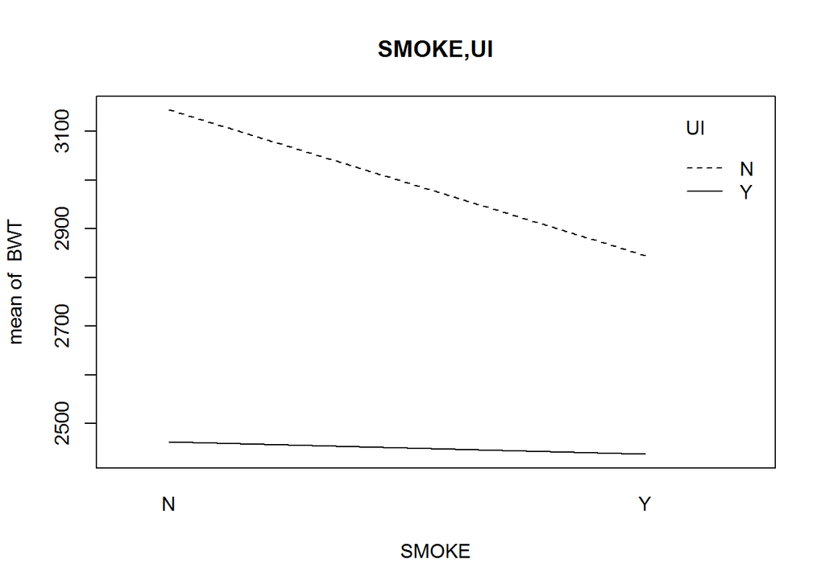

Nous pouvons voir que la courbe des moyennes de poids de naissance associées aux mères qui n’ont pas d’irritabilité utérine est plus élevée que celle de celles qui en ont, quelque soit le niveau de tabagisme de la mère. **Il semble donc avoir un véritable impact de l’uterus irritable sur le poids de naissance**.

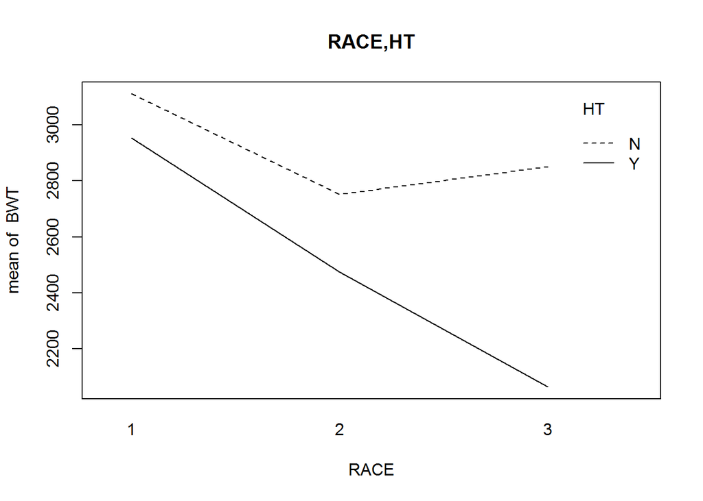

Nous pouvons voir que la courbe des moyennes de poids de naissance associées aux mères qui n’ont pas eu d’antécédents d’hypertensions est plus élevée que celle de celles qui en ont eu, quelque soit la race de la mère. **Il semble donc avoir un impact d’antécédents d’hypertensions sur le poids de naissance**.

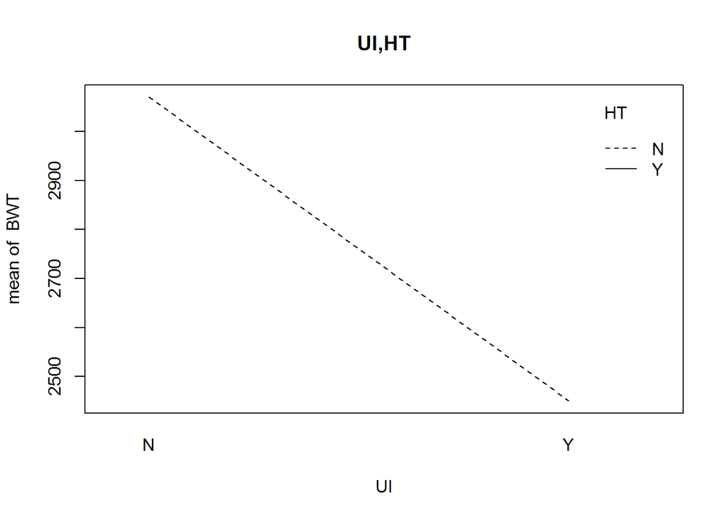

### 2) Analyse de la variance

**A) Modèle avec l’intéraction**

SMOKE et UI

| . | Df | Sum Sq | Mean Sq | F value | Pr(>F) |  |
| --- | --- | --- | --- | --- | --- | --- |
| UI | 1 | 8028747 | 8028747 | 16.7840 | 6.259e-05 |  |
| SMOKE | 1 | 2949940 | 2949940 | 6.1668 | 0.01391 |  |
| UI:SMOKE | 1 | 442511 | 442511 | 0.9251 | 0.33740 |  |
| Residuals | 185 | 88495854 | 478356 |  |  |  |

La dernière colonne donne les p-valeurs des différents tests on voit que les tests sur les facteurs **UI** et **SMOKE** sont significatifs (car 6.259e-05 et 0.01391 sont inférieur à 0.05).

Mais la p-valeur du test d’interaction **UI:SMOKE** est de 0.33740 ce qui est trop élevé .

**Donc, dans ce cas on ne peut pas rejeter l’hypothèse nulle au niveau habituel de 0.05 et nous considérons donc un modèle sans interaction.**

RACE et HT

| . | Df | Sum Sq | Mean Sq | F value | Pr(>F) |  |
| --- | --- | --- | --- | --- | --- | --- |
| HT | 1 | 2132014 | 2132014 | 4.2323 | 0.04108 |  |
| RACE | 2 | 4716128 | 2358064 | 4.6811 | 0.01041 |  |
| HT:RACE | 2 | 884006 | 442003 | 0.8774 | 0.41759 |  |
| Residuals | 183 | 92184904 | 503743 |  |  |  |

La dernière colonne donne les p-valeurs des différents tests on voit que les tests sur les facteurs **HT** et **RACE** sont significatifs(car 0.04108 et 0.01041 sont inférieur à 0.05).

Mais la p-valeur du test d’interaction **HT:RACE** est de 0.41759 ce qui est trop élevé .

**Donc, dans ce cas on ne peut pas rejeter l’hypothèse nulle au niveau habituel de 0.05 et nous considérons donc un modèle sans interaction.**

UI et HT

| . | Df | Sum Sq | Mean Sq | F value | Pr(>F) |  |
| --- | --- | --- | --- | --- | --- | --- |
| HT | 1 | 2132014 | 2132014 | 4.4694 | 0.03584 |  |
| UI | 1 | 9059202 | 9059202 | 18.9912 | 2.169e-05 |  |
| Residuals | 186 | 88725836 | 477021 |  |  |  |

La dernière colonne donne les p-valeurs des différents tests on voit que **les tests sur les facteurs HT et UI sont significatifs** (car 0.03584 et 2.169e-05 sont inférieur à 0.05).

Le coefficient **UI:HT** n’apparrait pas dans le tableau en effet **notre jeux de donné ne contient pas de femme ayant à la fois un uterus irritable et des antécédents d’hypertations, il aurait fallu en avoir quelque-une c’est une condition nécessaire sur les données pour l’analyse de la variance on devra alors considérer uniquement le modèle sans interractions.**.

**B) Modele sans interraction**

SMOKE et UI

| . | Df | Sum Sq | Mean Sq | F value | Pr(>F) |  |
| --- | --- | --- | --- | --- | --- | --- |
| UI | 1 | 8028747 | 8028747 | 16.7908 | 6.225e-05 |  |
| SMOKE | 1 | 2949940 | 2949940 | 6.1693 | 0.01388 |  |
| Residuals | 186 | 88938365 | 478163 |  |  |  |

RACE et HT

| . | Df | Sum Sq | Mean Sq | F value | Pr(>F) |  |
| --- | --- | --- | --- | --- | --- | --- |
| HT | 1 | 2132014 | 2132014 | 4.2380 | 0.04093 |  |
| RACE | 2 | 4716128 | 2358064 | 4.6873 | 0.01033 |  |
| Residuals | 185 | 93068910 | 503075 |  |  |  |

UI et HT

| . | Df | Sum Sq | Mean Sq | F value | Pr(>F) |  |
| --- | --- | --- | --- | --- | --- | --- |
| HT | 1 | 2132014 | 2132014 | 4.4694 | 0.03584 |  |
| UI | 1 | 9059202 | 9059202 | 18.9912 | 2.169e-05 |  |
| Residuals | 186 | 88725836 | 477021 |  |  |  |

Dans les 3 tableaux la dernière colonne donne les p-valeurs des différents tests on voit que les tests sur les coefficients **SMOKE**,**UI** resp (**HT** et **RACE**) resp (**HT** et **UI**) sont significatives car leurs p-values est inférieures à 0.05.

### 3) Coefficient $R^2$ et $R^2_a$ associés à chaque modèle

Tout d’abord $R^2=1 -\frac{SCR}{SCT}$ et $R^2_{adjusté} = 1 -\frac{SCR/n-k}{SCT/n-1}$ = $1 -\frac{CMR}{CMT}$ avec SCR la somme des carrés des résidus. SCT est la somme des carrés totaux. $CMR = \frac{SCRC}{n-|k|}$ et $CMT= \frac{SCT}{n-1}$ les carrés moyens avec k le nombre de facteur de notre modele et n-1 et n-|k| les degrés de liberté de SCR et SCT

La SCR mesure l’ajustement du modèle aux données. Elle est autant plus petite que l’ajustement est bon. Naturellement, on a intérêt de trouver un modèle dont la SCR est faible. Or, minimiser la SCR revient à maximiser le coefficient de détermination $R^2$. On cherche donc le modèle qui a le coefficient $R^2$ le plus proche de 1. Or, ce critère augmente toujours avec le nombre de variables pour une suite de modèles emboîtés, Le $R^2$ ajusté (Adjusted R-Squared) va alors tenir compte de ce nombre et sera donc plus correct. Au final on cherchera donc le modèle qui a **le coefficient $R^2$ ajusté le plus proche de 1**.

**Observons le tableau et les graphiques suivants tout en ne considérant pas le modèle avec intéraction de UI et HT :**

ai: Avec interraction si: Sans interraction

| . | Multiple R-squared | Adjusted R-squared |  |
| --- | --- | --- | --- |
| SMOKE et UI (ai) | 0.1143 | 0.09994 |  |
| RACE et HT(ai) | 0.07739 | 0.05218 |  |
| SMOKE et UI (si) | 0.1099 | 0.1003 |  |
| RACE et HT(si) | 0.06854 | 0.05343 |  |
| UI et HT(si) | 0.112 | 0.1025 |  |

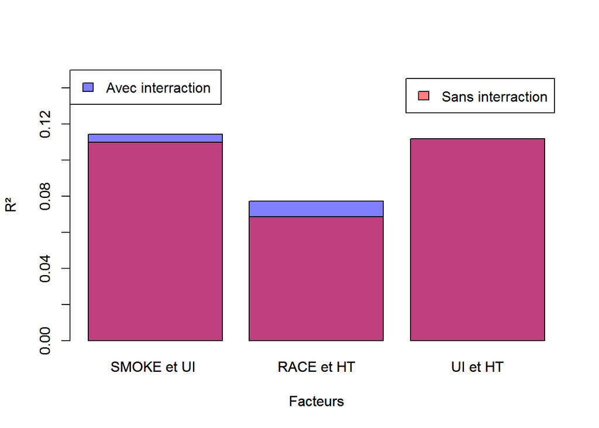

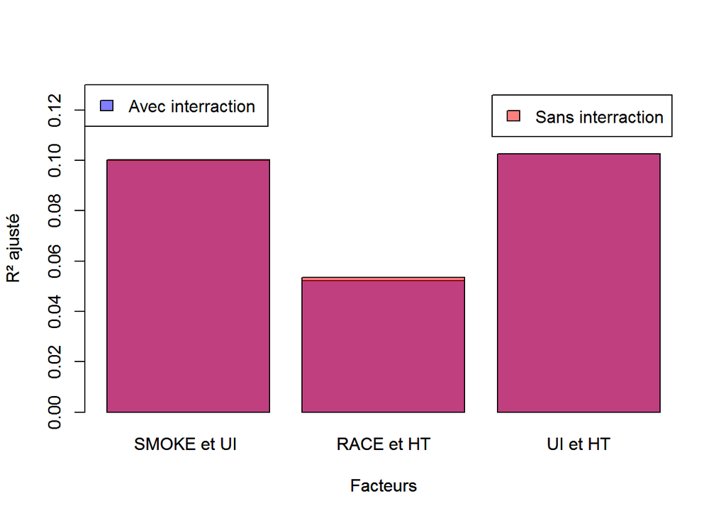

Grace au tableau et aux graphiques ci dessus on voit que **le coefficient R² du modèle avec interraction des facteurs SMOKE et UI est le plus proche de 1**; cependant pour **le coefficient R² ajusté c’est celui du modèles sans interraction des facteur UI er HT qui est le plus proche de 1** (0.1025)

On en deduit que **le modèles sans interraction des facteurs UI et HT est le meilleur modèle** puis vient le modèle sans interraction celui avec les facteurs **SMOKE et UI**.